# Fumia_META_profiles

Jonas BEAL

11/17/2017

## Objectives

Generate patients profiles from BRCA METABRIC data for further logical modelling.

# Independant omics profiles

## METABRIC dataset recap

More than 1800 patients with several kinds of omics data: exome-sequencing, Copy Number Alterations (CNA), RNA and clinical annotations.

Most patients have all omics data:

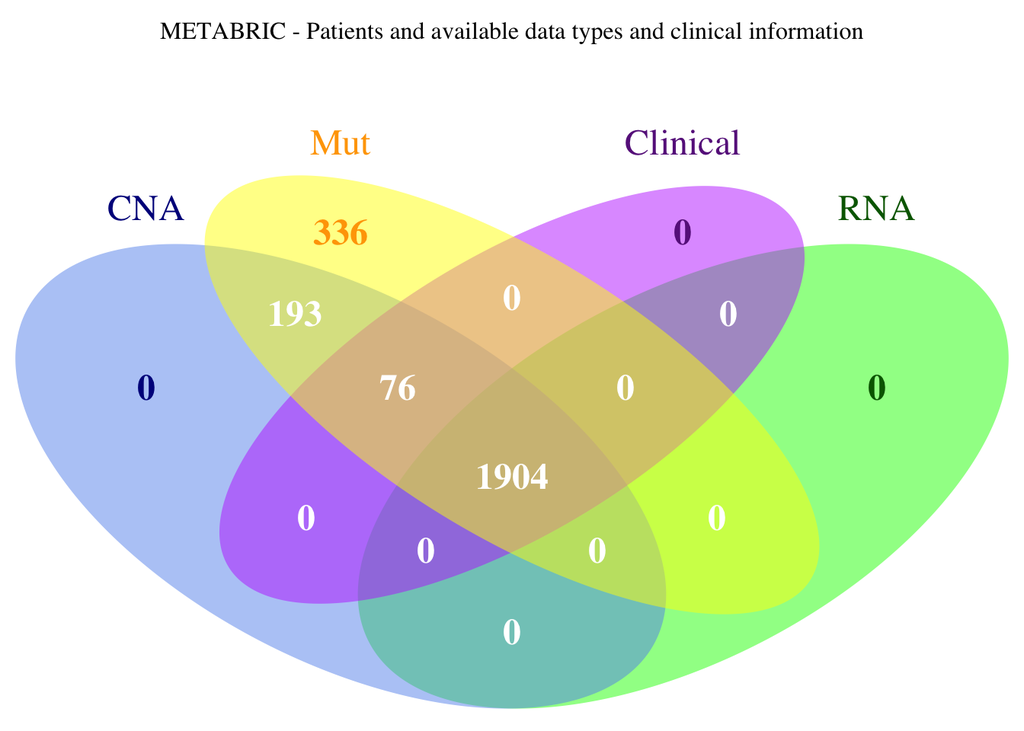

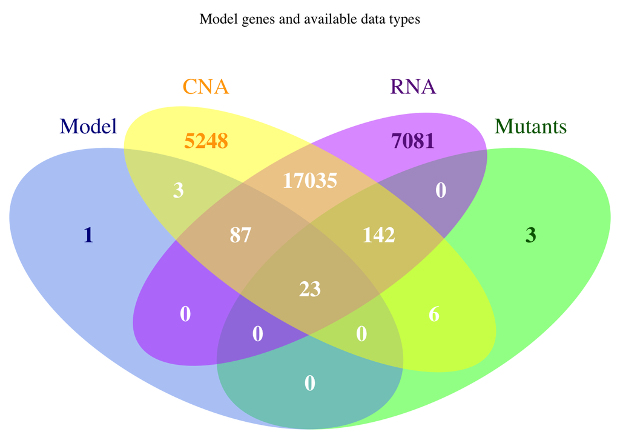

We investigate relations betwenn RNAseq data and BC subtypes. Subtypes have been defined based on PAM50 method. First, here is the distribution of BC subtypes across the cohort:

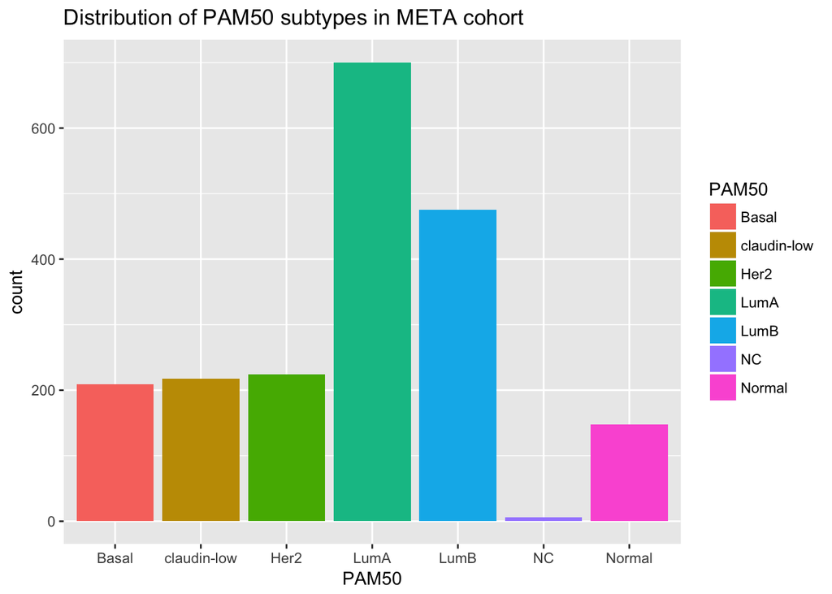

RNAseq is projected on PC1/PC2 space (from Principal Component Analysis), from PAM50 genes only (using only 47 out of 50 genes in PAM50 list present in RNAseq)

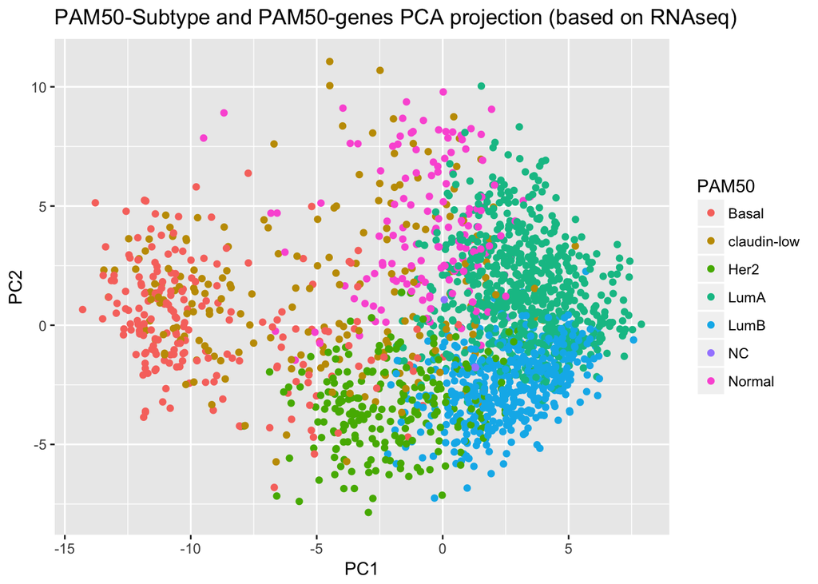

# Processing pipeline

## Mutations profiles

We need to assign Boolean effects to mutations: either 0 (inactivating) or 1 (activating). A mutation can stay unassigned in absence of any evidence.

Assignement methods and their respective influence:

```
## [1] "Sankey plots of mutation assignments depending on methods used"
```

[interactive chart not shown]

```
## [1] "Sankey plots of mutation assignments depending on methods used (restricted to model-related nodes)"
```

[interactive chart not shown]

Now we can summarize patient mutation profiles after processing. In following plots we focus on model-related genes only.

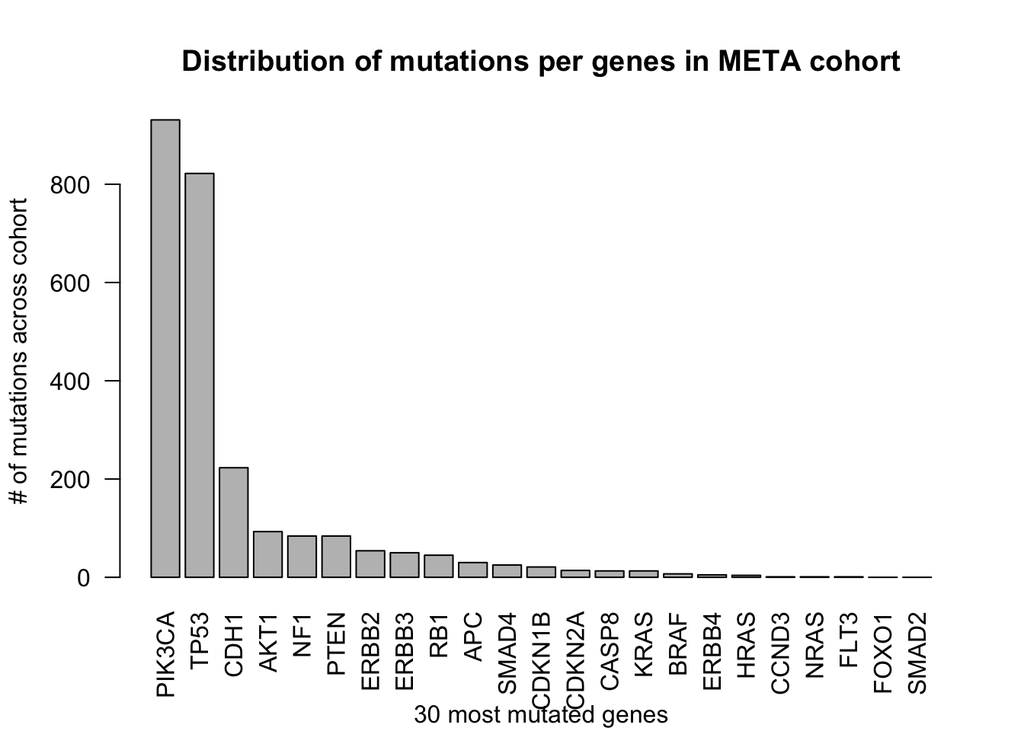

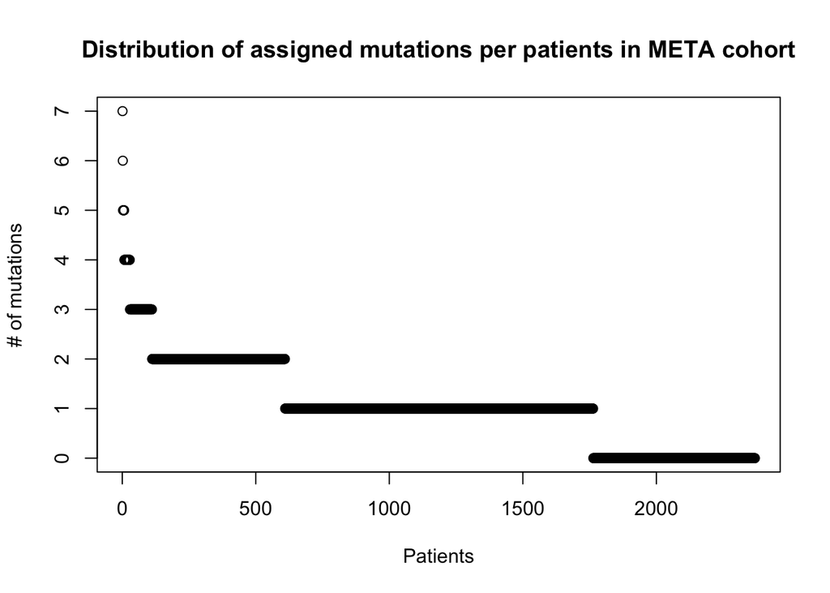

## CNA profiles

For CNA, we have decided to focus on stringent amplifications/deletions corresponding to +2/-2 GISTIC results. We produce the same kind of plots.

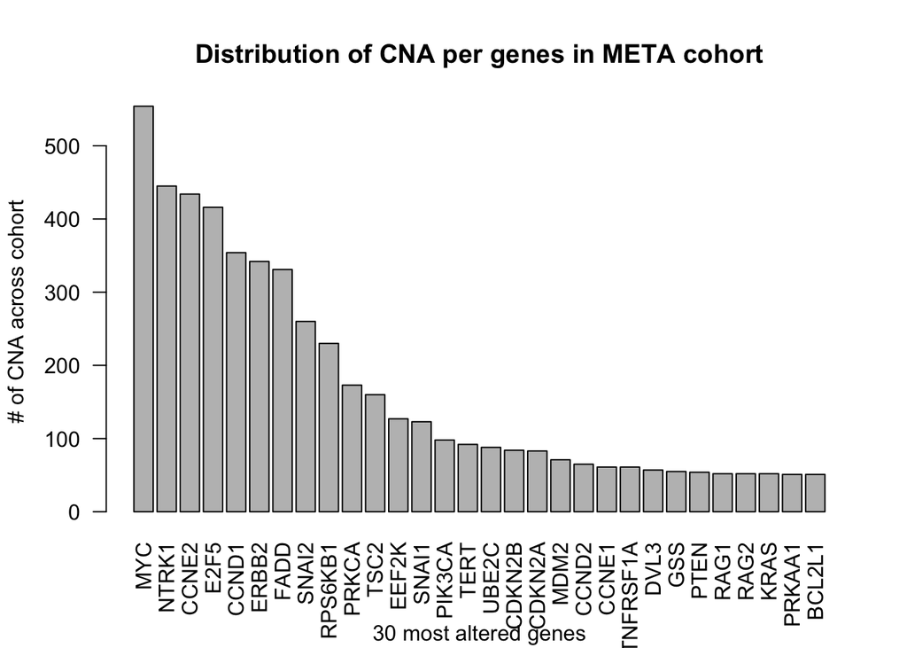

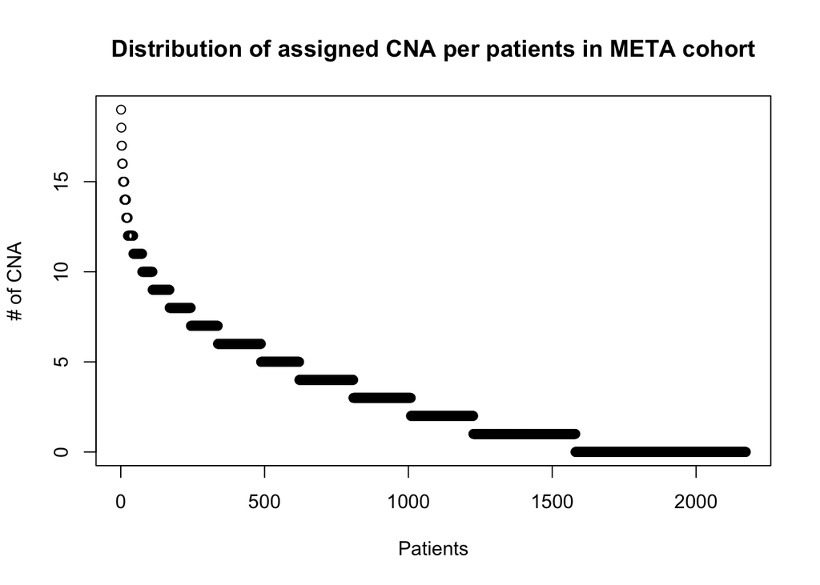

## RNA profiles

RNA data is intrinsically continuous and therefore require preliminary data processing. It is important to notice that METABRIC data comes from microarray.

### Binarization with classification tree

Now, what about the distribution of gene categories (Bimodal, Unimodal…) across the cohort?

```
## [1] "META assignments:"
```

[output not shown]

```
## [1] "META assignments for model-related nodes:"
```

[output not shown]

Here are some distributions plots randomly picked in each category in META cohort

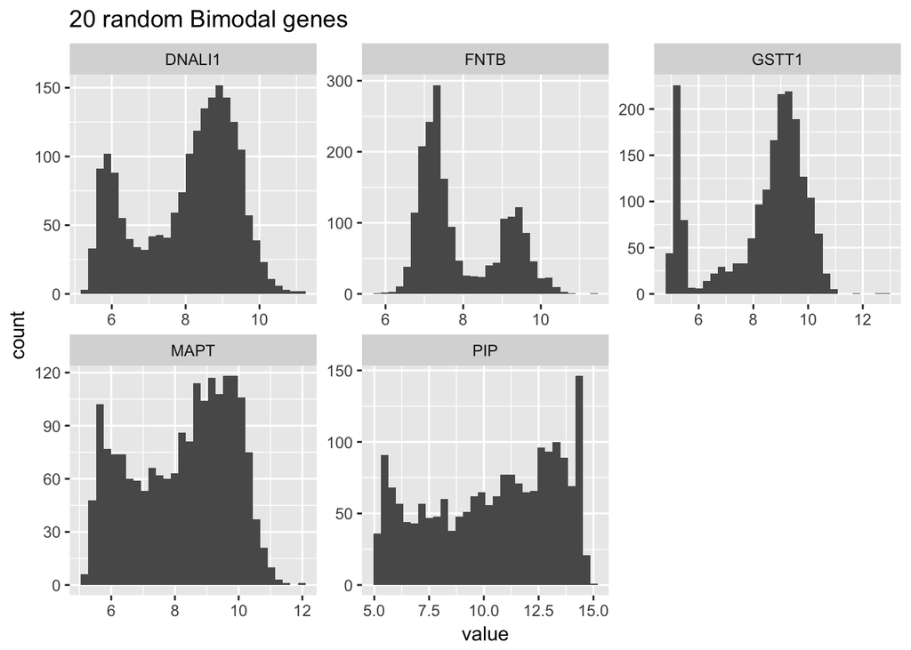

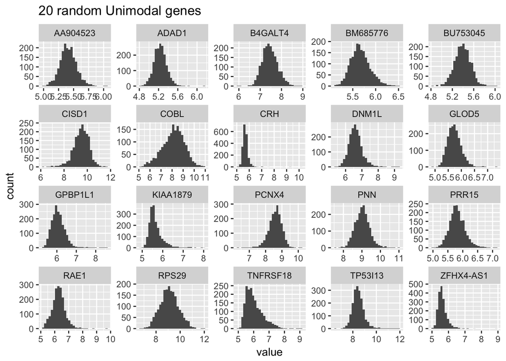

And depending on distribution category, we can perform binarization

```
## [1] "Bimodal example:"
```

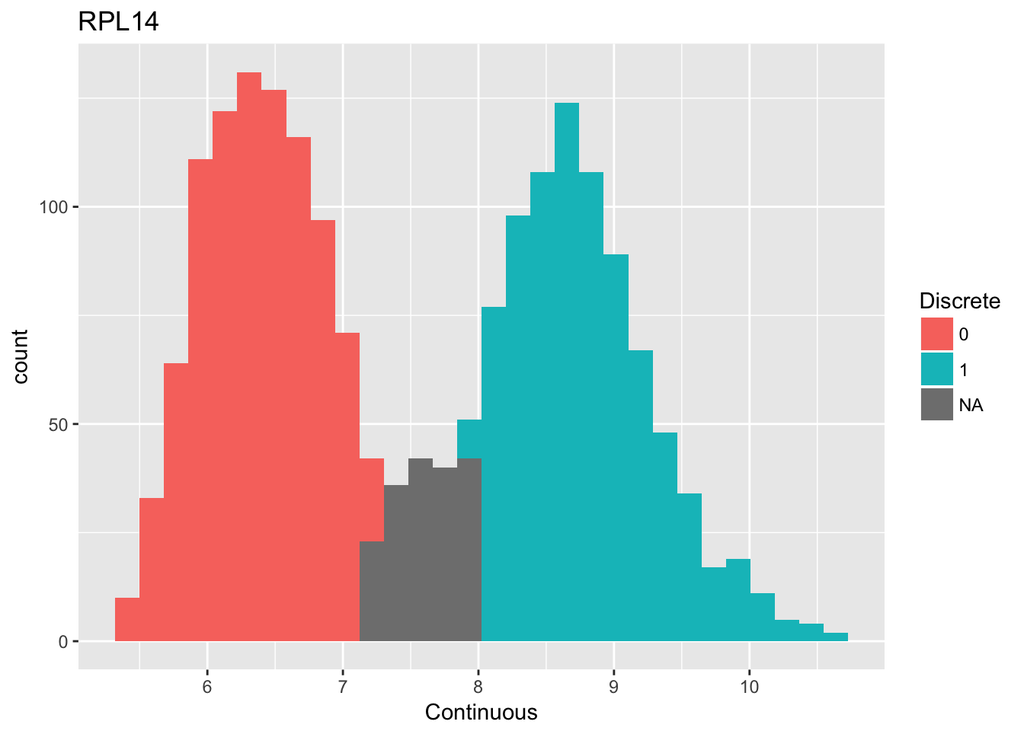

```
## [1] "Unimodal example:"
```

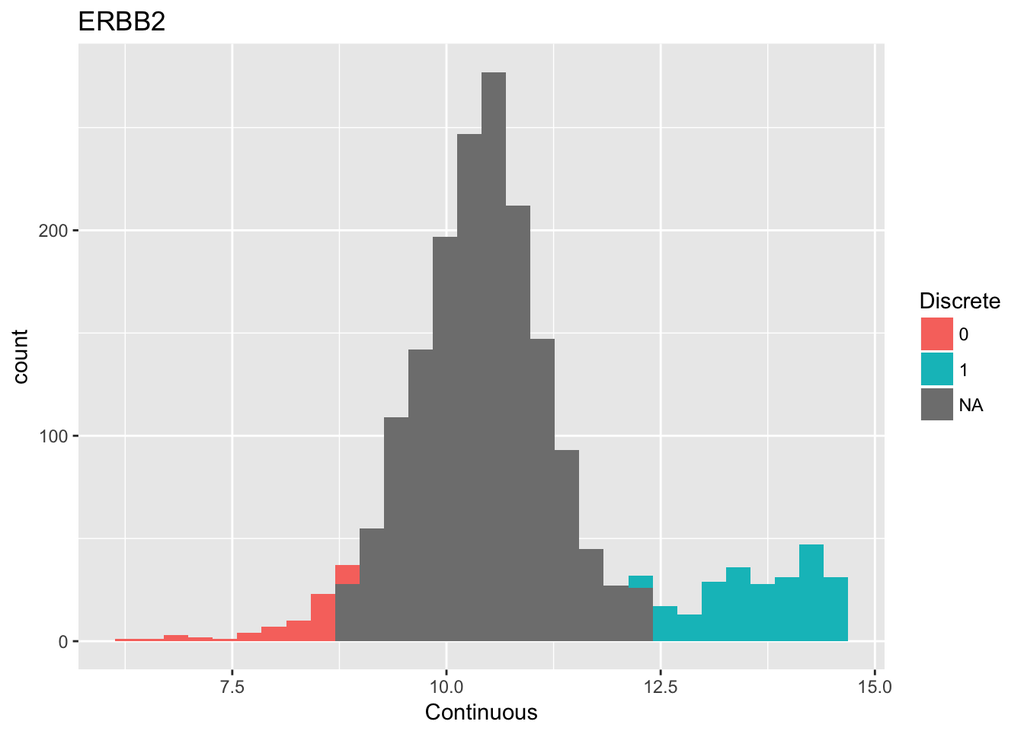

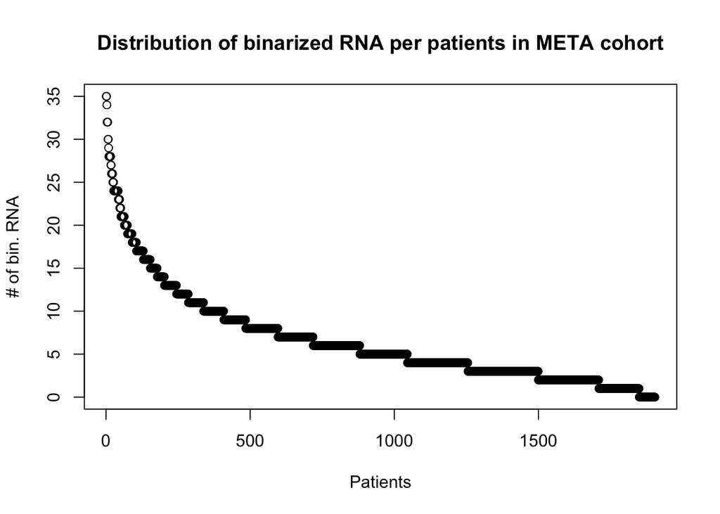

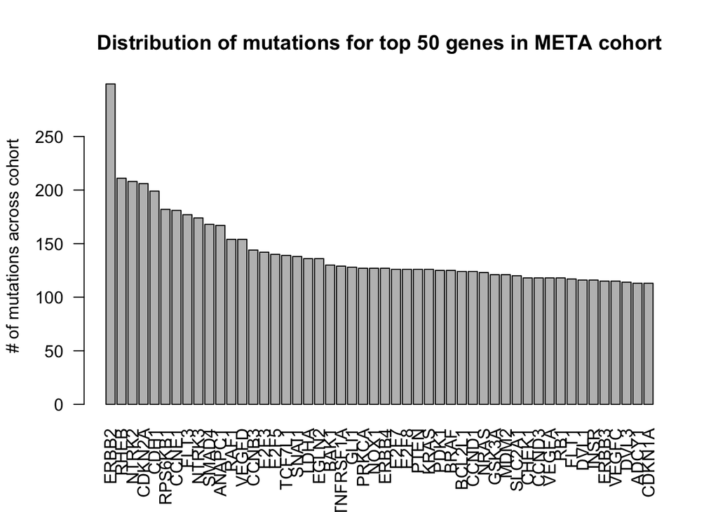

# Merged profiles

## Data types relations

Before merging independant profiles into multi-omics profiles, let’s have a look at relations between data types

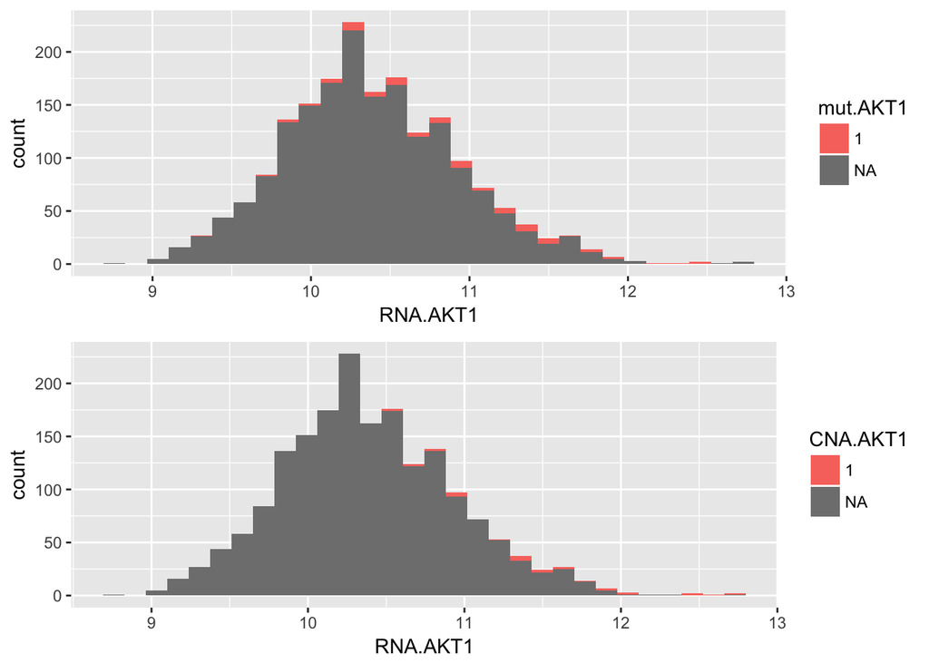

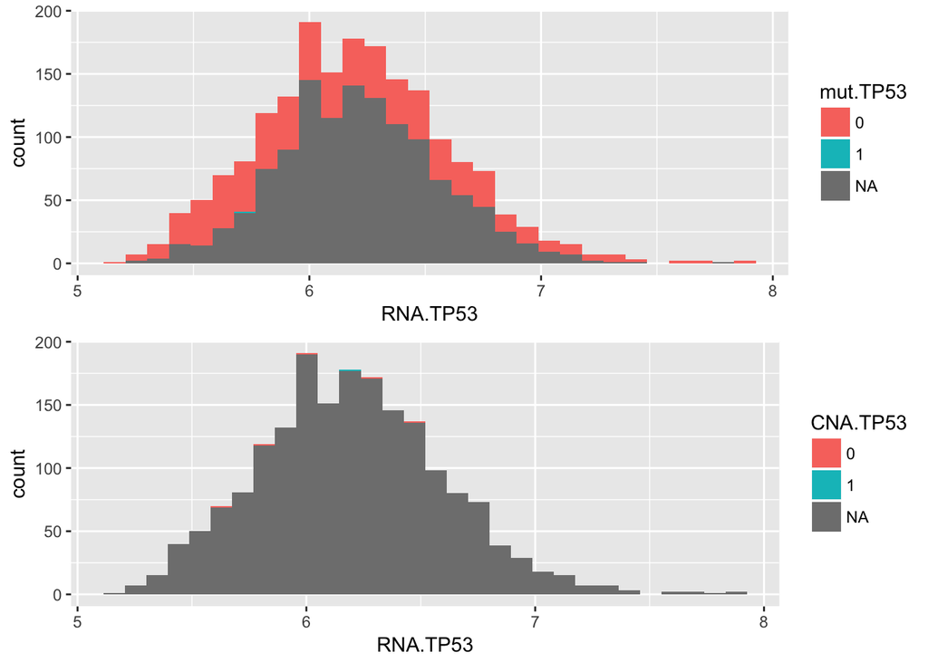

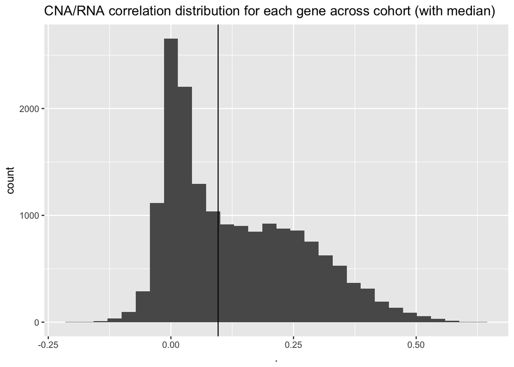

### Mutations and CNA

In particular, is there any mutation/CNA binary inconsistency?

| Patient | Gene | Mut | CNA |
| --- | --- | --- | --- |
| MTS-T1304 | NF1 | 0 | 1 |
| MB-0607 | ERBB2 | 0 | 1 |
| MB-3614 | RB1 | 0 | 1 |
| MB-4332 | CDKN1B | 0 | 1 |

In case of ambiguity, pritority is given to mutations over CNA

### CNA and RNA

| Patient | Gene | CNA | RNA |
| --- | --- | --- | --- |
| MB-0569 | BAD | 1 | 0 |
| MB-3502 | CASP8 | 1 | 0 |
| MB-6184 | COX4I2 | 1 | 0 |
| MB-0149 | CCND2 | 1 | 0 |
| MB-4660 | CCND2 | 1 | 0 |
| MB-5135 | CCND2 | 1 | 0 |
| MB-4426 | E2F5 | 1 | 0 |
| MB-5174 | E2F5 | 1 | 0 |
| MB-5190 | E2F5 | 1 | 0 |
| MB-3165 | E2F6 | 1 | 0 |
| MB-0569 | GLI1 | 1 | 0 |
| MB-2923 | MYC | 1 | 0 |
| MB-5174 | MYC | 1 | 0 |
| MB-0582 | CDKN2B | 1 | 0 |
| MB-5358 | CDKN1A | 1 | 0 |
| MB-5107 | PRKCA | 1 | 0 |
| MB-0079 | ARAF | 1 | 0 |
| MB-4224 | ARAF | 0 | 1 |
| MB-7198 | ARAF | 1 | 0 |
| MB-0291 | RAG1 | 1 | 0 |
| MB-0291 | RAG2 | 1 | 0 |
| MB-2753 | NOX1 | 1 | 0 |
| MB-4281 | ERBB4 | 0 | 1 |
| MB-0346 | FLT1 | 1 | 0 |
| MB-5259 | FLT4 | 1 | 0 |
| MB-0131 | NTRK1 | 1 | 0 |
| MB-0501 | NTRK1 | 1 | 0 |
| MB-2742 | NTRK1 | 1 | 0 |
| MB-2954 | NTRK1 | 1 | 0 |
| MB-3211 | NTRK1 | 1 | 0 |
| MB-4622 | NTRK1 | 1 | 0 |
| MB-5018 | NTRK1 | 1 | 0 |
| MB-7050 | NTRK1 | 1 | 0 |
| MB-7253 | NTRK3 | 1 | 0 |
| MB-4171 | SNAI2 | 1 | 0 |
| MB-4236 | SNAI2 | 1 | 0 |
| MB-4360 | SNAI2 | 1 | 0 |
| MB-5236 | SNAI2 | 1 | 0 |
| MB-7031 | SNAI2 | 1 | 0 |
| MB-4697 | SNAI1 | 1 | 0 |
| MB-5525 | SNAI1 | 1 | 0 |
| MB-7299 | SNAI1 | 1 | 0 |
| MB-0060 | TCF4 | 1 | 0 |
| MB-2753 | TCF4 | 1 | 0 |
| MB-0340 | TERT | 1 | 0 |
| MB-5208 | TERT | 1 | 0 |
| MB-3297 | TNFRSF1A | 1 | 0 |
| MB-0053 | TSC2 | 1 | 0 |
| MB-4224 | VEGFD | 0 | 1 |

In case of ambiguity, pritority is given to RNA over CNA

### Mut and RNA

| Patient | Gene | Mut | RNA |
| --- | --- | --- | --- |
| MB-0066 | CASP8 | 0 | 1 |
| MB-6273 | NF1 | 0 | 1 |
| MB-7215 | NF1 | 0 | 1 |
| MB-3452 | CDKN2A | 0 | 1 |
| MB-0100 | TP53 | 0 | 1 |
| MB-0107 | TP53 | 0 | 1 |
| MB-0149 | TP53 | 0 | 1 |
| MB-0164 | TP53 | 0 | 1 |
| MB-0191 | TP53 | 0 | 1 |
| MB-0214 | TP53 | 0 | 1 |
| MB-0259 | TP53 | 0 | 1 |
| MB-0278 | TP53 | 0 | 1 |
| MB-0340 | TP53 | 0 | 1 |
| MB-0396 | TP53 | 0 | 1 |
| MB-0400 | TP53 | 0 | 1 |
| MB-0516 | TP53 | 0 | 1 |
| MB-0582 | TP53 | 0 | 1 |
| MB-0874 | TP53 | 0 | 1 |
| MB-0895 | TP53 | 0 | 1 |
| MB-4715 | TP53 | 0 | 1 |
| MB-4732 | TP53 | 0 | 1 |
| MB-4770 | TP53 | 0 | 1 |
| MB-4792 | TP53 | 0 | 1 |
| MB-4865 | TP53 | 0 | 1 |
| MB-4911 | TP53 | 0 | 1 |
| MB-5205 | TP53 | 0 | 1 |
| MB-5298 | TP53 | 0 | 1 |
| MB-5378 | TP53 | 0 | 1 |
| MB-5421 | TP53 | 0 | 1 |
| MB-5440 | TP53 | 0 | 1 |
| MB-5526 | TP53 | 0 | 1 |
| MB-5548 | TP53 | 0 | 1 |
| MB-5559 | TP53 | 0 | 1 |
| MB-5560 | TP53 | 0 | 1 |
| MB-6055 | TP53 | 0 | 1 |
| MB-6143 | TP53 | 0 | 1 |
| MB-7031 | TP53 | 0 | 1 |
| MB-7036 | TP53 | 0 | 1 |
| MB-7089 | TP53 | 0 | 1 |
| MB-7165 | TP53 | 0 | 1 |
| MB-7262 | TP53 | 0 | 1 |
| MB-0133 | PIK3CA | 1 | 0 |
| MB-0308 | PIK3CA | 1 | 0 |
| MB-0317 | PIK3CA | 1 | 0 |
| MB-0422 | PIK3CA | 1 | 0 |
| MB-0451 | PIK3CA | 1 | 0 |
| MB-0486 | PIK3CA | 1 | 0 |
| MB-4012 | PIK3CA | 1 | 0 |
| MB-4426 | PIK3CA | 1 | 0 |
| MB-5163 | PIK3CA | 1 | 0 |
| MB-5204 | PIK3CA | 1 | 0 |
| MB-0470 | ERBB2 | 1 | 0 |
| MB-0365 | RB1 | 0 | 1 |

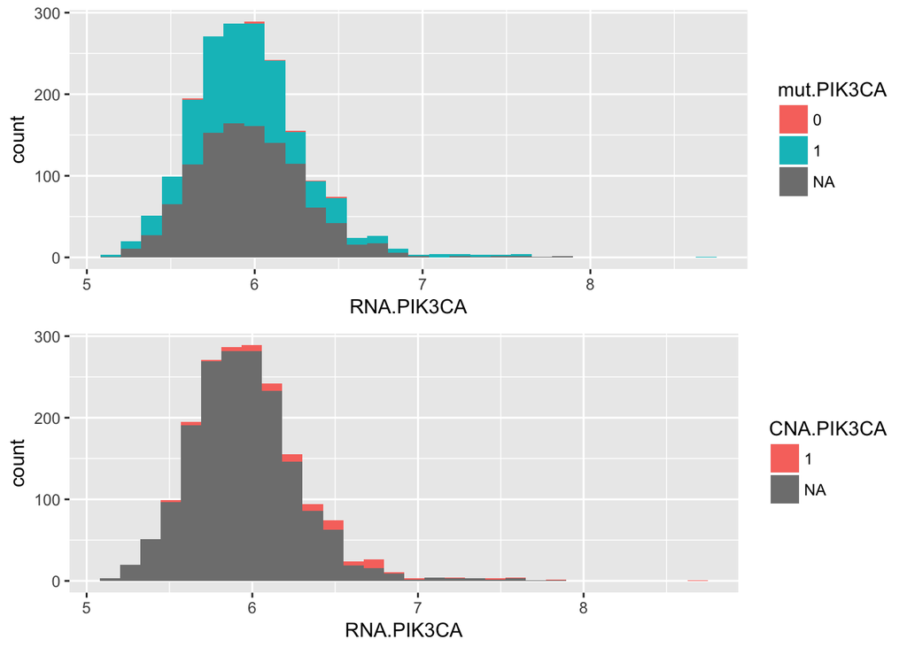